# Stats 506 Group Project

Group 10: Karthik G, Xinjun Li and Jingyan Lu

12/9/2019

# Introduction

##### Our project aims to answer the question:

##### “Is salt intake associated with blood pressure? If so, to what extent is that relationship mediated or moderated by age or waist size?”

##### By raising the question, we want to know whether the salt intake behavior of a person is related to the person’s blood pressure levels and want to know further if this relationship is dependent on the waist measurement of the person.

##### The analysis would be a moderation analysis testing whether there exists a relationship between salt intake and blood pressure levels and if this relationship is moderated by waist measurement.

##### As a follow up analysis, we will study “whether the salt intake habit of a person is related to the person’s blood pressure levels and identify whether age is a mechanism underlying the relationship between the two”, i.e., is age a mediator between the relationship between salt intake and blood pressure levels? This would be a mediation analysis with a confidence interval-based bootstrapping approach. This analysis will use demographics, nutrients_1day, and blood_pressure data.

# Data

##### We use [NHANES](https://wwwn.cdc.gov/nchs/nhanes/continuousnhanes/default.aspx) data in 2015-2016 for analysis. Data of salt intake and people’s diastole and systole blood pressure are needed in both moderation and mediation analysis. You can find them in the datasets [Dietary Interview - Total Nutient intakes, First Day](https://wwwn.cdc.gov/Nchs/Nhanes/2015-2016/DR1TOT_I.htm), [Blood Pressure](https://wwwn.cdc.gov/Nchs/Nhanes/2015-2016/BPX_I.htm) respectively.

##### For the moderation analysis, we use another dataset [Body Measures](https://wwwn.cdc.gov/Nchs/Nhanes/2015-2016/BMX_I.htm) for data of waist measurement.

##### For the mediation analysis, data of participants’ age from [Demographic variables and Sample Weights](https://wwwn.cdc.gov/Nchs/Nhanes/2015-2016/DEMO_I.htm) is used.

# Methods

# Moderation and Mediation

## R

### Load the data

```r
demographics = read.xport("C:/Users/djbranglab-admin/Desktop/stats506-master/stats506-master/RawData/Demographics_2015_16.XPT")
blood_pressure = read.xport("C:/Users/djbranglab-admin/Desktop/stats506-master/stats506-master/RawData/Blood_Pressure_2015_16.XPT")
nutrients_1day = read.xport("C:/Users/djbranglab-admin/Desktop/stats506-master/stats506-master/RawData/Dietary_nutrients_firstday_2015_16.XPT")
BMI = read.xport("C:/Users/djbranglab-admin/Desktop/stats506-master/stats506-master/RawData/Body_measures_2015_16.XPT")
```

### Data processing

```r
blood_pressure = blood_pressure %>%
  select(SEQN, BPXSY1, BPXSY2, BPXSY3, BPXDI1, BPXDI2, BPXDI3) %>%
  rowwise() %>%
  mutate(DI = mean(c(BPXDI1, BPXDI2, BPXDI3), na.rm=TRUE),
         SY = mean(c(BPXSY1, BPXSY2, BPXSY3), na.rm = TRUE)) %>%
  select(SEQN, DI, SY)

demographics = demographics %>%
  select(SEQN, RIDAGEYR)

nutrients_1day = nutrients_1day %>%
  select(SEQN, DBD100)

BMI = BMI %>%
  select(SEQN, BMXWAIST)

data = demographics %>%
  left_join(BMI, by = "SEQN") %>%
  left_join(nutrients_1day, by = "SEQN") %>%
  left_join(blood_pressure, by = "SEQN")


data = data[complete.cases(data), ]
```

#### Center means to reduce multicolinearity

```r
data[c("RIDAGEYR", "BMXWAIST", "DBD100", "DI", "SY")] =
  lapply(data[c("RIDAGEYR", "BMXWAIST", "DBD100", "DI", "SY")],
         function(x) scale(x, center=TRUE, scale=FALSE))
```

### Analyse the relationship between salt intake and two kinds of blood pressure

#### For diastole blood pressure

```r
model_DI = lm(DI ~ DBD100, data)
summary(model_DI)
```

```
##
## Call:
## lm(formula = DI ~ DBD100, data = data)
##
## Residuals:
##     Min      1Q  Median      3Q     Max
## -67.247  -7.689   0.311   8.311  60.645
##
## Coefficients:
##               Estimate Std. Error t value Pr(>|t|)
## (Intercept) -5.601e-17  1.950e-01   0.000 1.000000
## DBD100       8.918e-01  2.296e-01   3.884 0.000104 ***
## ---
## Signif. codes:  0 '***' 0.001 '**' 0.01 '*' 0.05 '.' 0.1 ' ' 1
##
## Residual standard error: 13.34 on 4680 degrees of freedom
## Multiple R-squared:  0.003213,   Adjusted R-squared:  0.003
## F-statistic: 15.08 on 1 and 4680 DF,  p-value: 0.0001042
```

#### For systole blood pressure

```r
model_SY = lm(SY ~ DBD100, data)
summary(model_SY)
```

```
##
## Call:
## lm(formula = SY ~ DBD100, data = data)
##
## Residuals:
##     Min      1Q  Median      3Q     Max
## -47.011 -12.074  -2.740   8.322  86.593
##
## Coefficients:
##              Estimate Std. Error t value Pr(>|t|)
## (Intercept) 3.995e-15  2.526e-01   0.000 1.000000
## DBD100      1.135e+00  2.975e-01   3.816 0.000137 ***
## ---
## Signif. codes:  0 '***' 0.001 '**' 0.01 '*' 0.05 '.' 0.1 ' ' 1
##
## Residual standard error: 17.29 on 4680 degrees of freedom
## Multiple R-squared:  0.003102,   Adjusted R-squared:  0.002889
## F-statistic: 14.56 on 1 and 4680 DF,  p-value: 0.0001373
```

##### Both p-values are less than 0.001, which shows strong evidence that salt intake have siginificant influence on both kinds of blood pressure.

### Moderation part

The structural model for the moderation analysis can be defined as seen in Figure 1

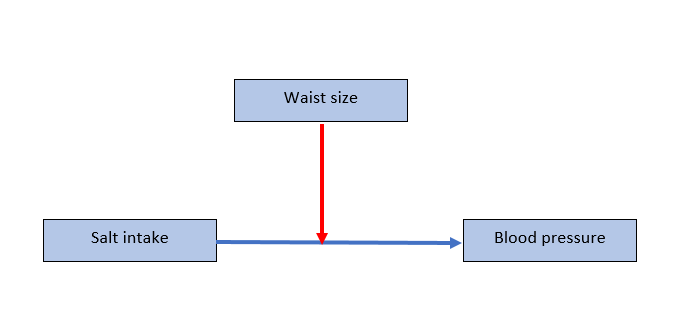

Fig 1: Structural model for the moderation analysis

##### We perform moderation to test if the relationship is dependent on the waist size. Three levels of a moderator(mean, one standard deviation above the mean and one standard deviation below the mean) is chosen.

#### Moderation at mean for diastole blood pressure

```r
moderation_DI = lm(DI ~ DBD100 + BMXWAIST + DBD100 * BMXWAIST, data)
summary(moderation_DI)
```

```
##
## Call:
## lm(formula = DI ~ DBD100 + BMXWAIST + DBD100 * BMXWAIST, data = data)
##
## Residuals:
##     Min      1Q  Median      3Q     Max
## -74.261  -7.147   0.498   7.943  53.281
##
## Coefficients:
##                  Estimate Std. Error t value Pr(>|t|)
## (Intercept)      0.010034   0.186699   0.054  0.95714
## DBD100           0.596273   0.219951   2.711  0.00673 **
## BMXWAIST         0.207160   0.009824  21.086  < 2e-16 ***
## DBD100:BMXWAIST -0.009955   0.012081  -0.824  0.41000
## ---
## Signif. codes:  0 '***' 0.001 '**' 0.01 '*' 0.05 '.' 0.1 ' ' 1
##
## Residual standard error: 12.75 on 4678 degrees of freedom
## Multiple R-squared:  0.09015,    Adjusted R-squared:  0.08957
## F-statistic: 154.5 on 3 and 4678 DF,  p-value: < 2.2e-16
```

#### Moderation at one standard deviation above mean for diastole blood pressure

```r
data$BMXWAIST_high = data$BMXWAIST + sd(data$BMXWAIST)
moderation_DI_high = lm(DI ~ DBD100 + BMXWAIST_high + DBD100 * BMXWAIST_high, data)
summary(moderation_DI_high)
```

```
##
## Call:
## lm(formula = DI ~ DBD100 + BMXWAIST_high + DBD100 * BMXWAIST_high,
##     data = data)
##
## Residuals:
##     Min      1Q  Median      3Q     Max
## -74.261  -7.147   0.498   7.943  53.281
##
## Coefficients:
##                       Estimate Std. Error t value Pr(>|t|)
## (Intercept)          -3.928731   0.264392 -14.860   <2e-16 ***
## DBD100                0.785543   0.313193   2.508   0.0122 *
## BMXWAIST_high         0.207160   0.009824  21.086   <2e-16 ***
## DBD100:BMXWAIST_high -0.009955   0.012081  -0.824   0.4100
## ---
## Signif. codes:  0 '***' 0.001 '**' 0.01 '*' 0.05 '.' 0.1 ' ' 1
##
## Residual standard error: 12.75 on 4678 degrees of freedom
## Multiple R-squared:  0.09015,    Adjusted R-squared:  0.08957
## F-statistic: 154.5 on 3 and 4678 DF,  p-value: < 2.2e-16
```

#### Modetation at one standard deviation below mean for diastole blood pressure

```r
data$BMXWAIST_low = data$BMXWAIST - sd(data$BMXWAIST)
moderation_DI_low = lm(DI ~ DBD100 + BMXWAIST_low + DBD100 * BMXWAIST_low, data)
summary(moderation_DI_low)
```

```
##
## Call:
## lm(formula = DI ~ DBD100 + BMXWAIST_low + DBD100 * BMXWAIST_low,
##     data = data)
##
## Residuals:
##     Min      1Q  Median      3Q     Max
## -74.261  -7.147   0.498   7.943  53.281
##
## Coefficients:
##                      Estimate Std. Error t value Pr(>|t|)
## (Intercept)          3.948800   0.263806  14.969   <2e-16 ***
## DBD100               0.407004   0.322794   1.261    0.207
## BMXWAIST_low         0.207160   0.009824  21.086   <2e-16 ***
## DBD100:BMXWAIST_low -0.009955   0.012081  -0.824    0.410
## ---
## Signif. codes:  0 '***' 0.001 '**' 0.01 '*' 0.05 '.' 0.1 ' ' 1
##
## Residual standard error: 12.75 on 4678 degrees of freedom
## Multiple R-squared:  0.09015,    Adjusted R-squared:  0.08957
## F-statistic: 154.5 on 3 and 4678 DF,  p-value: < 2.2e-16
```

##### Since the regression coefficient for the interation term is not significant with p value 0.41, there does not exist a significant moderation effect. the effect of salt intake on diastole blood pressure may not depend on waist size.

#### Simple Slope analysis for diastole blood pressure

##### We find beta0 and beta1 values of the independent variable DBD100 (salt intake) from the three regression models: (1) with the moderator held at mean (2) with the moderator held at one standard deviation below mean (3) with the moderator held at one standard deviation above mean.

##### Then, for each of these three models, we predict the dependent variable Y = beta0 + beta1 * X (here Y is blood pressure DI and X is the salt intake DBD100). By analysing the characteristic of Y at three levels of the moderator, we can compare the behaviors of moderator at three levels. In our case, we are seeing if people with waist size one standard deviation below mean and one standard deviation above mean have different blood pressure characteristics compared to people with waist size at mean.

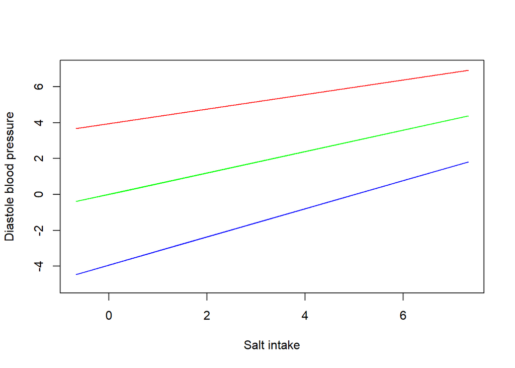

```r
# moderator is at mean: b0 = 0.010034, b1 = 0.596273
meanDI = moderation_DI$coefficients[1] + moderation_DI$coefficients[2] * data$DBD100

# moderator is one standard deviation above mean: b0 = -3.928731, b1 = 0.785543
highDI = moderation_DI_high$coefficients[1] + moderation_DI_high$coefficients[2] * data$DBD100

# moderator is one standard deviation below mean: bo = 3.948800, b1 = 0.407004
lowDI = moderation_DI_low$coefficients[1] + moderation_DI_low$coefficients[2] * data$DBD100

# plot the three dependent values vs salt intake
plot(data$DBD100, meanDI, type = "l", col = "green", ylim = c(-5, 7), xlab = "Salt intake", ylab = "Diastole blood pressure")
lines(data$DBD100, lowDI, col = "red")
lines(data$DBD100, highDI, col = "blue")
```

#### Moderation at mean for systole blood pressure

```r
moderation_SY = lm(SY ~ DBD100 + BMXWAIST + DBD100 * BMXWAIST, data)
summary(moderation_SY)
```

```
##
## Call:
## lm(formula = SY ~ DBD100 + BMXWAIST + DBD100 * BMXWAIST, data = data)
##
## Residuals:
##     Min      1Q  Median      3Q     Max
## -44.138 -10.182  -2.532   6.798  92.036
##
## Coefficients:
##                  Estimate Std. Error t value Pr(>|t|)
## (Intercept)     -0.009924   0.230167  -0.043   0.9656
## DBD100           0.610168   0.271162   2.250   0.0245 *
## BMXWAIST         0.379788   0.012112  31.357   <2e-16 ***
## DBD100:BMXWAIST  0.009845   0.014894   0.661   0.5086
## ---
## Signif. codes:  0 '***' 0.001 '**' 0.01 '*' 0.05 '.' 0.1 ' ' 1
##
## Residual standard error: 15.72 on 4678 degrees of freedom
## Multiple R-squared:  0.1763, Adjusted R-squared:  0.1757
## F-statistic: 333.7 on 3 and 4678 DF,  p-value: < 2.2e-16
```

#### Moderation at one standard deviation above mean for systole blood pressure

```r
data$BMXWAIST_high = data$BMXWAIST + sd(data$BMXWAIST)
moderation_SY_high = lm(SY ~ DBD100 + BMXWAIST_high + DBD100 * BMXWAIST_high, data)
summary(moderation_SY_high)
```

```
##
## Call:
## lm(formula = SY ~ DBD100 + BMXWAIST_high + DBD100 * BMXWAIST_high,
##     data = data)
##
## Residuals:
##     Min      1Q  Median      3Q     Max
## -44.138 -10.182  -2.532   6.798  92.036
##
## Coefficients:
##                       Estimate Std. Error t value Pr(>|t|)
## (Intercept)          -7.230880   0.325950 -22.184   <2e-16 ***
## DBD100                0.422982   0.386113   1.095    0.273
## BMXWAIST_high         0.379788   0.012112  31.357   <2e-16 ***
## DBD100:BMXWAIST_high  0.009845   0.014894   0.661    0.509
## ---
## Signif. codes:  0 '***' 0.001 '**' 0.01 '*' 0.05 '.' 0.1 ' ' 1
##
## Residual standard error: 15.72 on 4678 degrees of freedom
## Multiple R-squared:  0.1763, Adjusted R-squared:  0.1757
## F-statistic: 333.7 on 3 and 4678 DF,  p-value: < 2.2e-16
```

```r
data$BMXWAIST_low = data$BMXWAIST - sd(data$BMXWAIST)
moderation_SY_low = lm(SY ~ DBD100 + BMXWAIST_low + DBD100 * BMXWAIST_low, data)
summary(moderation_SY_low)
```

```
##
## Call:
## lm(formula = SY ~ DBD100 + BMXWAIST_low + DBD100 * BMXWAIST_low,
##     data = data)
##
## Residuals:
##     Min      1Q  Median      3Q     Max
## -44.138 -10.182  -2.532   6.798  92.036
##
## Coefficients:
##                     Estimate Std. Error t value Pr(>|t|)
## (Intercept)         7.211033   0.325227  22.172   <2e-16 ***
## DBD100              0.797353   0.397949   2.004   0.0452 *
## BMXWAIST_low        0.379788   0.012112  31.357   <2e-16 ***
## DBD100:BMXWAIST_low 0.009845   0.014894   0.661   0.5086
## ---
## Signif. codes:  0 '***' 0.001 '**' 0.01 '*' 0.05 '.' 0.1 ' ' 1
##
## Residual standard error: 15.72 on 4678 degrees of freedom
## Multiple R-squared:  0.1763, Adjusted R-squared:  0.1757
## F-statistic: 333.7 on 3 and 4678 DF,  p-value: < 2.2e-16
```

##### Since the regression coefficient for the interation term is not significant with p value 0.51, there does not exist a significant moderation effect. the effect of salt intake on systole blood pressure may not depend on waist size as well.

#### Simple slope analysis for systole blood pressure

##### The method is the same as diastole blood pressure.

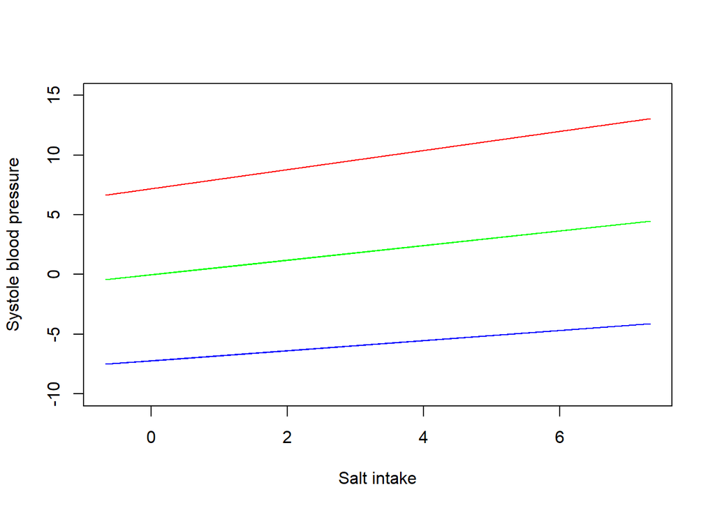

```r
# moderator is at mean: b0 = -0.009924, b1 = 0.610168
meanSY = moderation_SY$coefficients[1] + moderation_SY$coefficients[2] * data$DBD100

# moderator is one standard deviation above mean: b0 = -7.230880, b1 = 0.422982
highSY = moderation_SY_high$coefficients[1] + moderation_SY_high$coefficients[2] * data$DBD100

# moderator is one standard deviation below mean: bo = 7.221033, b1 = 0.797353
lowSY = moderation_SY_low$coefficients[1] + moderation_SY_low$coefficients[2] * data$DBD100

# plot the three dependent values vs salt intake
plot(data$DBD100, meanSY, type = "l", col = "green", ylim = c(-10, 15), xlab = "Salt intake", ylab = "Systole blood pressure")
lines(data$DBD100, lowSY, col = "red")
lines(data$DBD100, highSY, col = "blue")
```

### Mediation Part

##### We perform mediation to test if the relationship between salt intake and blood pressure mediated by age.

##### First, test if there is relationship between age and salt intake, since mediation makes sense only if they have relationship

```r
age_salt_DI = lm(RIDAGEYR ~ DBD100, data)
summary(age_salt_DI)
```

```
##
## Call:
## lm(formula = RIDAGEYR ~ DBD100, data = data)
##
## Residuals:
##     Min      1Q  Median      3Q     Max
## -44.005 -19.872  -3.024  17.823  43.433
##
## Coefficients:
##               Estimate Std. Error t value Pr(>|t|)
## (Intercept) -2.276e-15  3.145e-01   0.000        1
## DBD100       2.305e+00  3.704e-01   6.223 5.31e-10 ***
## ---
## Signif. codes:  0 '***' 0.001 '**' 0.01 '*' 0.05 '.' 0.1 ' ' 1
##
## Residual standard error: 21.52 on 4680 degrees of freedom
## Multiple R-squared:  0.008206,   Adjusted R-squared:  0.007994
## F-statistic: 38.72 on 1 and 4680 DF,  p-value: 5.309e-10
```

##### The p_value is 5.31e-10. They have strong relationship.

#### Second, perform the mediation analysis

##### For diastole blood pressure

```r
mediation_DI = lm(DI ~ DBD100 + RIDAGEYR, data)
summary(mediation_DI)
```

```
##
## Call:
## lm(formula = DI ~ DBD100 + RIDAGEYR, data = data)
##
## Residuals:
##     Min      1Q  Median      3Q     Max
## -73.075  -7.197   0.551   7.921  60.624
##
## Coefficients:
##              Estimate Std. Error t value Pr(>|t|)
## (Intercept) 3.158e-16  1.881e-01   0.000   1.0000
## DBD100      5.152e-01  2.224e-01   2.316   0.0206 *
## RIDAGEYR    1.634e-01  8.743e-03  18.687   <2e-16 ***
## ---
## Signif. codes:  0 '***' 0.001 '**' 0.01 '*' 0.05 '.' 0.1 ' ' 1
##
## Residual standard error: 12.87 on 4679 degrees of freedom
## Multiple R-squared:  0.07244,    Adjusted R-squared:  0.07204
## F-statistic: 182.7 on 2 and 4679 DF,  p-value: < 2.2e-16
```

#### Third, perform the mediation through bootstrapping

##### For diastole blood pressure

```r
mediation_boot_DI1 = mediation(x = data$DBD100,
                               mediator = data$RIDAGEYR,
                               dv = data$DI,
                               conf.level = 0.95,
                               bootstrap = TRUE,
                               B = 1000,
                               which.boot = "Percentile")
```

```
## [1] "Bootstrap resampling has begun. This process may take a considerable amount of time if the number of replications is large, which is optimal for the bootstrap procedure."
```

```r
mediation_boot_DI1
```

```
##                                            Estimate CI.Lower_Percentile
## Indirect.Effect                        0.3765500632        0.2417266153
## Indirect.Effect.Partially.Standardized 0.0281847931        0.0179361306
## Index.of.Mediation                     0.0239330262        0.0152094472
## R2_4.5                                 0.0021491333        0.0008131071
## R2_4.6                                 0.0005699203        0.0002309858
## R2_4.7                                 0.0078676552        0.0034869809
## Ratio.of.Indirect.to.Total.Effect      0.4222366268        0.2597972556
## Ratio.of.Indirect.to.Direct.Effect     0.7308123818        0.3441475544
## Success.of.Surrogate.Endpoint          0.3869472836        0.2192077751
## Residual.Based_Gamma                   0.0043638728        0.0018209201
## Residual.Based.Standardized_gamma      0.0039579315        0.0017272597
## SOS                                    0.6689288496        0.4549695811
##                                        CI.Upper_Percentile
## Indirect.Effect                                0.523903996
## Indirect.Effect.Partially.Standardized         0.039173862
## Index.of.Mediation                             0.033135073
## R2_4.5                                         0.003927246
## R2_4.6                                         0.001086320
## R2_4.7                                         0.013583307
## Ratio.of.Indirect.to.Total.Effect              0.788824927
## Ratio.of.Indirect.to.Direct.Effect             3.211576957
## Success.of.Surrogate.Endpoint                  0.598631034
## Residual.Based_Gamma                           0.007760888
## Residual.Based.Standardized_gamma              0.007001687
## SOS                                            0.951041052
```

##### The indirect effect (0.37655) and its confidence interval is different from zero. Age is a mediator between salt intake and diastole blood pressure.

[figure not shown]

Fig 2: Direct and indirect effects of the mediation analysis for Diastole

##### The effect of salt intake on diastole blood pressure still exists(p-value is 0.021), but in a smaller magnitude.Age partially mediates between salt intake and diastole blood pressure.

##### For systole blood pressure

```r
mediation_SY = lm(SY ~ DBD100 + RIDAGEYR, data)
summary(mediation_SY)
```

```
##
## Call:
## lm(formula = SY ~ DBD100 + RIDAGEYR, data = data)
##
## Residuals:
##     Min      1Q  Median      3Q     Max
## -44.567  -8.973  -1.109   7.366  73.387
##
## Coefficients:
##              Estimate Std. Error t value Pr(>|t|)
## (Intercept) 5.036e-15  2.077e-01   0.000    1.000
## DBD100      8.128e-02  2.456e-01   0.331    0.741
## RIDAGEYR    4.574e-01  9.655e-03  47.375   <2e-16 ***
## ---
## Signif. codes:  0 '***' 0.001 '**' 0.01 '*' 0.05 '.' 0.1 ' ' 1
##
## Residual standard error: 14.21 on 4679 degrees of freedom
## Multiple R-squared:  0.3263, Adjusted R-squared:  0.326
## F-statistic:  1133 on 2 and 4679 DF,  p-value: < 2.2e-16
```

##### The effect of salt intake on systole blood pressure disappear (p-value is 0.741), age fully mediates salt intake and systole blood pressure.

#### Perform the mediation through bootstrapping for systole

```r
mediation_boot_SY1 = mediation(x = data$DBD100,
                               mediator = data$RIDAGEYR,
                               dv = data$SY,
                               conf.level = 0.95,
                               bootstrap = TRUE,
                               B = 1000,
                               which.boot = "Percentile")
```

```
## [1] "Bootstrap resampling has begun. This process may take a considerable amount of time if the number of replications is large, which is optimal for the bootstrap procedure."
```

```r
mediation_boot_SY1
```

```
##                                            Estimate CI.Lower_Percentile
## Indirect.Effect                         1.054137647        7.340856e-01
## Indirect.Effect.Partially.Standardized  0.060897024        4.261502e-02
## Index.of.Mediation                      0.051710512        3.575419e-02
## R2_4.5                                  0.003086452        3.390407e-04
## R2_4.6                                  0.002660286        1.274321e-03
## R2_4.7                                  0.008153615        3.914354e-03
## Ratio.of.Indirect.to.Total.Effect       0.928416123        6.309828e-01
## Ratio.of.Indirect.to.Direct.Effect     12.969626170       -9.018531e+01
## Success.of.Surrogate.Endpoint           0.492651297        2.579669e-01
## Residual.Based_Gamma                    0.003966790        1.519824e-03
## Residual.Based.Standardized_gamma       0.003752141        1.406059e-03
## SOS                                     0.994917800        4.283526e-01
##                                        CI.Upper_Percentile
## Indirect.Effect                                1.398421719
## Indirect.Effect.Partially.Standardized         0.080692284
## Index.of.Mediation                             0.068121049
## R2_4.5                                         0.006803132
## R2_4.6                                         0.004591180
## R2_4.7                                         0.014108740
## Ratio.of.Indirect.to.Total.Effect              1.759216010
## Ratio.of.Indirect.to.Direct.Effect            77.448611107
## Success.of.Surrogate.Endpoint                  0.726548333
## Residual.Based_Gamma                           0.007516563
## Residual.Based.Standardized_gamma              0.007269277
## SOS                                            0.999956211
```

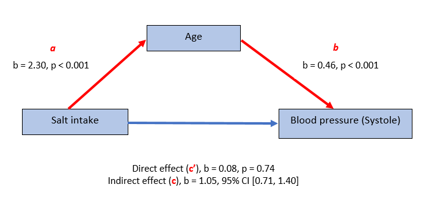

##### The estimate indirect effect(1.054) and its confidence interval is different from zero. Age is a mediator between salt intake and systole blood pressure.

## SAS

```r
libname results 'C:/Users/djbranglab-admin/Desktop/stats506-master/stats506-master/results';
libname rawdata 'C:/Users/djbranglab-admin/Desktop/stats506-master/stats506-master/RawData';
libname home 'C:/Users/djbranglab-admin/Desktop/stats506-master/stats506-master/home';
```

### Load the data

```r
%let demographics = 'C:/Users/djbranglab-admin/Desktop/stats506-master/stats506-master/RawData/demographics_15_16.csv';
%let BMI = 'C:/Users/djbranglab-admin/Desktop/stats506-master/stats506-master/RawData/Body_measures_2015_16.csv';
%let blood_pressure = 'C:/Users/djbranglab-admin/Desktop/stats506-master/stats506-master/RawData/Blood_Pressure_2015_16.csv';
%let nutrients_1day = 'C:/Users/djbranglab-admin/Desktop/stats506-master/stats506-master/RawData/Dietary_nutrients_firstday_2015_16.csv';

/* Import demographic data */
  proc import file = &demographics
out=home.demographics dbms=csv replace;
guessingrows=max;
getnames = Yes ;
run;

/* Import BMI data */
  proc import file = &BMI
out=home.BMI dbms=csv replace;
guessingrows=max;
getnames = Yes ;
run;

/* Import blood pressure data */
  proc import file = &blood_pressure
out=home.blood_pressure  dbms=csv replace;
guessingrows=max;
getnames = Yes ;
run;

/* Import nutrients data */
  proc import file = &nutrients_1day
out=home.nutrients_1day  dbms=csv replace;
guessingrows=max;
getnames = Yes ;
run;
```

### Data processing

```r
/* Merge all required data with SEQN as key*/
  proc sql;
create table home.merged_data as select
A.SEQN, A.RIDAGEYR,
B.BMXWAIST,
C.DBD100,
D.BPXSY1, D.BPXSY2, D.BPXSY3, D.BPXDI1, D.BPXDI2, D.BPXDI3 from
home.demographics as A inner join
home.BMI as B on
A.SEQN = B.SEQN inner join
home.nutrients_1day as C on
A.SEQN = C.SEQN inner join
home.blood_pressure as D on
A.SEQN = D.SEQN;
quit;

/* Find mean of systole and diastole from all three observations*/
  data home.mean_merged_data(DROP=BPXSY1 BPXSY2 BPXSY3 BPXDI1 BPXDI2 BPXDI3);
set home.merged_data;
BPXSY=mean(of BPXSY1-BPXSY3);
BPXDI=mean(of BPXDI1-BPXDI3);
run;

/* Drop rows with missing values*/
  data home.mean_merged_data;
set home.mean_merged_data;
if not cmiss(BMXWAIST,DBD100,BPXSY,BPXDI);
run;
```

#### Center means to reduce multicolinearity

```r
proc sql;
create table home.mean_centered_data as
select SEQN,
RIDAGEYR - mean(RIDAGEYR) as RIDAGEYRmc,
BMXWAIST - mean(BMXWAIST) as BMXWAISTmc,
DBD100 - mean(DBD100) as DBD100mc,
BPXDI - mean(BPXDI) as BPXDImc,
BPXSY - mean(BPXSY) as BPXSYmc
from home.mean_merged_data;
quit;
```

#### Create the moderator variables at one SD above and below mean and the interaction terms

```r
/* Create + and - one SD of the dependent variable for moderation analysis */
proc sql;
create table home.mean_centered_data as
select *,
BMXWAISTmc - std(BMXWAISTmc) as BMXWAISTlow,
BMXWAISTmc + std(BMXWAISTmc) as BMXWAISThigh
from home.mean_centered_data;
quit;

/* Create the interaction term for use in the moderator model */
data home.mean_centered_data;
set home.mean_centered_data;
DBD100mc_BMXWAISTmc=DBD100mc*BMXWAISTmc;
DBD100mc_BMXWAISTlow=DBD100mc*BMXWAISTlow;
DBD100mc_BMXWAISThigh=DBD100mc*BMXWAISThigh;
run;
```

### Analyse the relationship between salt intake and two kinds of blood pressure

#### For diastole blood pressure

```r
proc reg data= home.mean_centered_data;
model BPXDImc = DBD100mc;
title ' Regression model / testing relationship between Diastole and salt intake' ;
run;
```

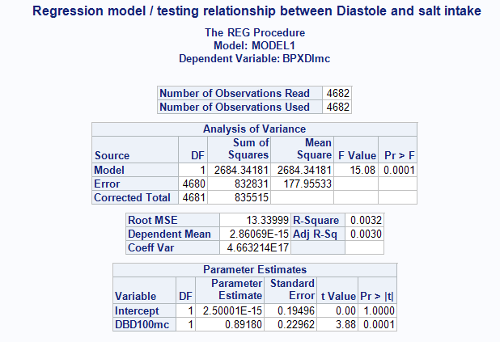

#### For systole blood pressure

```r
proc reg data= home.mean_centered_data;
model BPXSYmc = DBD100mc;
title ' Regression model / testing relationship between Systole and salt intake' ;
run;
```

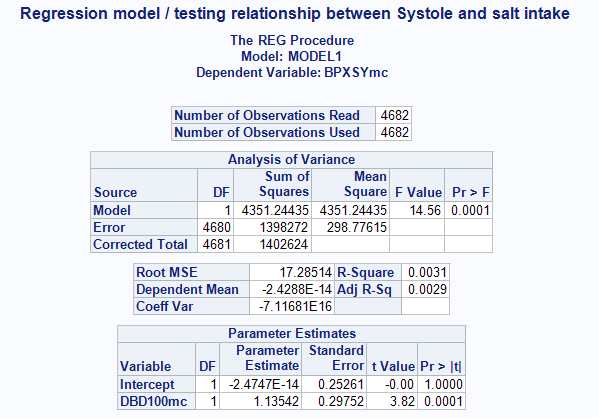

##### Both p-values are less than 0.001, which shows strong evidence that salt intake have siginificant influence on both kinds of blood pressure.

### Moderation part

##### We perform moderation to test if the relationship is dependent on the waist size. Three levels of a moderator(mean, one standard deviation above the mean and one standard deviation below the mean) is chosen.

#### Moderation at mean for diastole blood pressure

```r
proc reg data=home.mean_centered_data;
model BPXDImc = DBD100mc BMXWAISTmc DBD100mc_BMXWAISTmc / pcorr2 scorr2;
title ' Regression model / testing moderator effect of waist size on diastole and salt intake at mean' ;
run;
```

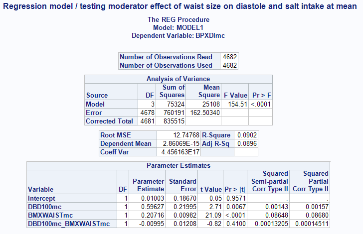

#### Moderation at one standard deviation above mean for diastole blood pressure

```r
proc reg data=home.mean_centered_data;
model BPXDImc = DBD100mc BMXWAISTmc DBD100mc_BMXWAISThigh / pcorr2 scorr2;
title ' Regression model / testing moderator effect of waist size on diastole and salt intake one SD above mean' ;
run;
```

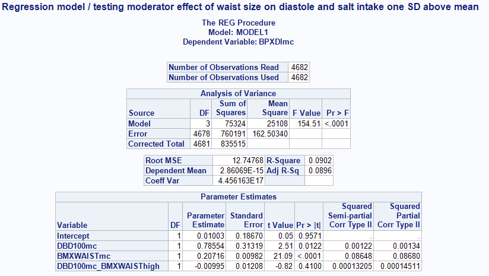

#### Moderation at one standard deviation below mean for diastole blood pressure

```r
proc reg data=home.mean_centered_data;
model BPXDImc = DBD100mc BMXWAISTlow DBD100mc_BMXWAISTlow / pcorr2 scorr2;
title ' Regression model / testing moderator effect of waist size on diastole and salt intake one SD below mean' ;
run;
```

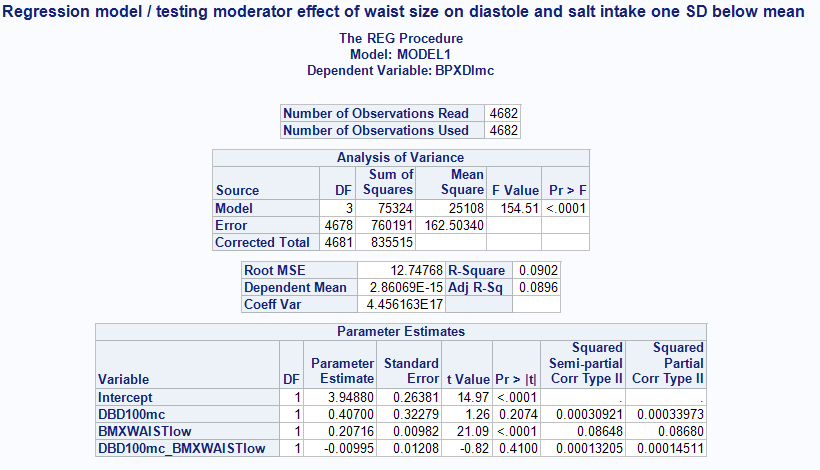

##### Since the regression coefficient for the interation term is not significant with p value 0.41, there does not exist a significant moderation effect. the effect of salt intake on diastole blood pressure may not depend on waist size.

#### Moderation at mean for systole blood pressure

```r
proc reg data=home.mean_centered_data;
model BPXSYmc = DBD100mc BMXWAISTmc DBD100mc_BMXWAISTmc / pcorr2 scorr2;
title ' Regression model / testing moderator effect of waist size on systole and salt intake at mean' ;
run;
```

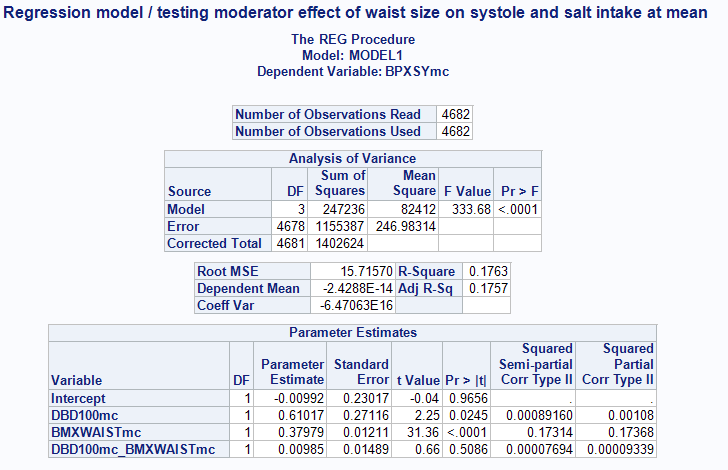

#### Moderation at one standard deviation above mean for systole blood pressure

```r
proc reg data=home.mean_centered_data;
model BPXSYmc = DBD100mc BMXWAISThigh DBD100mc_BMXWAISThigh / pcorr2 scorr2;
title ' Regression model / testing moderator effect of waist size on systole and salt intake one SD above mean' ;
run;
```

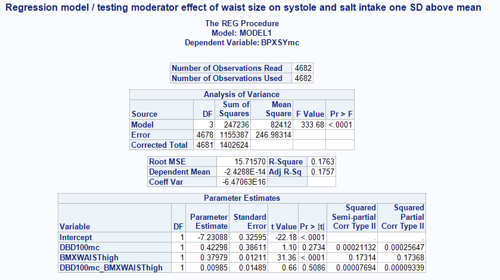

#### Moderation at one standard deviation below mean for systole blood pressure

```r
proc reg data=home.mean_centered_data;
model BPXSYmc = DBD100mc BMXWAISTlow DBD100mc_BMXWAISTlow / pcorr2 scorr2;
title ' Regression model / testing moderator effect of waist size on systole and salt intake one SD below mean' ;
run;
```

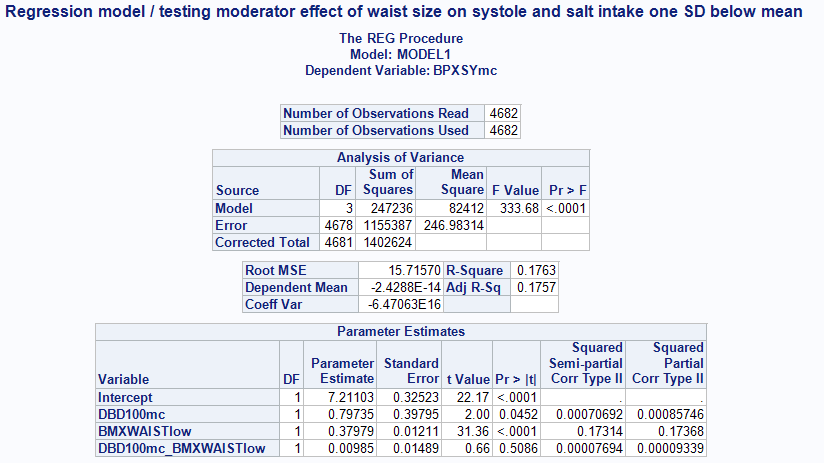

##### Since the regression coefficient for the interation term is not significant with p value 0.51, there does not exist a significant moderation effect. the effect of salt intake on systole blood pressure may not depend on waist size as well.

### Mediation Part

##### We perform mediation to test if the relationship between salt intake and blood pressure mediated by age.

##### First, test if there is relationship between age and salt intake, since mediation makes sense only if they have relationship

```r
proc reg data = home.mean_centered_data;
model RIDAGEYRmc = DBD100mc;
title ' Regression model / Checking relationship between age and salt intake' ;
run;
```

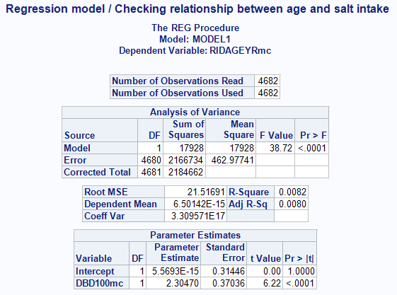

##### The p_value is 5.31e-10. They have strong relationship.

#### Second, perform the mediation

##### For diastole blood pressure

```r
proc causalmed data=home.mean_centered_data;
model BPXDImc = DBD100mc RIDAGEYRmc;
mediator RIDAGEYRmc = DBD100mc;
title ' Regression model / check the effect of age as a mediator between the relationship of Diastolic BP and salt intake' ;
run;
```

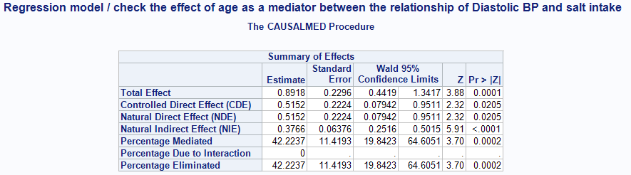

##### The effect of salt intake on diastole blood pressure still exists(p-value is 0.021), but in a smaller magnitude.Age partially mediates between salt intake and diastole blood pressure.

##### For systole blood pressure

```r
proc causalmed data=home.mean_centered_data;
model BPXSYmc = DBD100mc RIDAGEYRmc;
mediator RIDAGEYRmc = DBD100mc;
title ' Regression model / check the effect of age as a mediator between the relationship of Systolic BP and salt intake' ;
run;
```

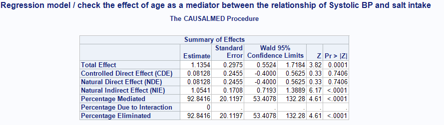

##### The effect of salt intake on systole blood pressure disappear (p-value is 0.741), age fully mediates salt intake and systole blood pressure.

#### Third, perform the mediation through bootstrapping

##### For diastole blood pressure

```r
proc causalmed data=home.mean_centered_data;
model BPXDImc = DBD100mc RIDAGEYRmc;
mediator RIDAGEYRmc = DBD100mc;
bootstrap NBOOT = 1000;
title ' Regression model / check the effect of age as a mediator between the relationship of Diastolic BP and salt intake using bootstrap' ;
run;
```

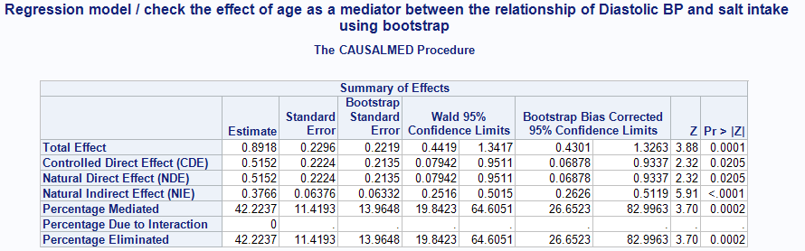

[figure not shown]

Direct and indirect effects of the mediation analysis for Diastole